# 그룹스터디 1

Hyundo Im

1st Meeting

## The Process of R

첫번째 명심해야할 점: 모든 오픈소스가 그렇듯, 쓰는 사람에 따라서 R 또한 그 쓰임새는 그냥 엑셀의 대체재 일수도, 또는 뭐든 가능케 할 놀라운 프로그래밍 언어가 될 수도 있습니다.

두번째 명심해야할 점: 데이터 분석의 종류에 따라서는 R보다는 STATA 또는 엑셀, 그리고 SPSS가 더 효율적일 수도 있습니다. 예: econometric만 할 경우 STATA, Factor Analysis, Frequency Analysis 등의 경우 SPSS, 다양한 표의 작성이나 Hierarchical table, 그리고 빠른 customizing을 요할 경우 Excel의 성능이 R보다 훨씬 성능이 좋습니다.

## 기본적인 R 커맨드(1)

- 사칙연산

```r
4 + 5
```

```
## [1] 9
```

```r
10 -5
```

```
## [1] 5
```

```r
8/5
```

```
## [1] 1.6
```

```r
8*5
```

```
## [1] 40
```

변수 정의

```r
x <- 8
y <- 2
x^y
```

```
## [1] 64
```

## 기본적인 R 커맨드(1)

List

```r
this_list <- c(1,2,3,4,5,6,6)
this_list
```

```
## [1] 1 2 3 4 5 6 6
```

Sequence - seq() 는 예를 들어 0~100까지 특정 수의 배수들만 call하고 싶을때 자주 사용합니다.

예를 들어,

```r
seq(0,10,1)
```

```
##  [1]  0  1  2  3  4  5  6  7  8  9 10
```

```r
x<-seq(0,1,0.1)
```

- Repitition - rep()

```r
rep(0,10)
```

```
##  [1] 0 0 0 0 0 0 0 0 0 0
```

```r
y<-rep(1,10)
y
```

```
##  [1] 1 1 1 1 1 1 1 1 1 1
```

## Working Directory

Working directory 는 일종의 “작업장”과 같은 개념입니다. R과 같은 오픈소스는 많은 경우에 직접 본인이 작업하고 싶은 파일이나 데이터의 “위치”를 직접 입력해야 하는 경우가 많은데, 그것을 일일이 적으려면 공간낭비 및 시간낭비가 상당합니다(제 얘깁니다…). R은 RSTUDIO가 “Import Dataset”이라는 콘솔을 이용하여 데이터를 R 로 불러올 수 있기는 합니다만, 그걸로는 부족할 때가 있습니다. 얘를 들어, 사용해야 하는 데이터 셋의 갯수가 여러개 일때, 일일이 콘솔로 불러 오는것도 귀찮아 집니다.

이와 같은 “귀찮은” 프로세스를 줄일 수 있는것이 `setwd()' 입니다. 얘를 들어 제가 사용하고 싶은 데이터가`C:\Users\imhyu\Desktop\Data Science\Study Group\data\`에 있을때, 아래와 같이

```r
setwd("C:\\Users\\imhyu\\Desktop\\Data Science\\Study Group\\data\\")
getwd()
```

```
## [1] "C:/Users/imhyu/Desktop/Data Science/Study Group/data"
```

getwd()를 통해 현재의 working directory의 위치를 확인할 수 있습니다.

## 어떤 데이터를 가져올 수 있는가

단적으로 얘기하자면, 본인 역량대로… 아는 패키지의 갯수와 그 패키지들을 자유로히 사용할 수 있다면, 다른 오픈소스들 처럼 R 또한 거의 모든 종류의 데이터를 끌고 오는것이 가능합니다. 다음에는 STATA의 dta, SAS 등의 데이터를 가져오는 작업도 해보겠습니다.

만약 stata의 dta등의 파일들을 끌고 오는것에 관심이 있으시다면, `foreign` 패키지를 알아보시는 것도 좋을 겁니다. stata의 dta는 상당히 가벼운 데이터 종류이기에, 괜찮은 데이터파일이라고 생각합니다.

빅데이터에서 개인적으로 가장 가벼운 데이터의 종류는 메모장 파일입니다(txt). 보안에 문제가 많기는 합니다만, 모든 데이터 종류 중 메모장만큼 가벼운 데이터 종류는 보기 힘듭니다.

## 기본 데이터

STATA나 SAS를 써보신 분들은 아시겠지만, 이 프로그램들은 처음 시작하는 사용자들을 위한 “초보용” 기본 데이터셋이 존재합니다 (당연한 것이긴 합니다만…).

STATA의 튜토리얼을 해보신 분들은 mtcars나 iris 데이터셋을 보신 적이 있을겁니다. R 또한 이러한 dataset들이 존재합니다.

```r
head(iris)
```

```
##   Sepal.Length Sepal.Width Petal.Length Petal.Width Species
## 1          5.1         3.5          1.4         0.2  setosa
## 2          4.9         3.0          1.4         0.2  setosa
## 3          4.7         3.2          1.3         0.2  setosa
## 4          4.6         3.1          1.5         0.2  setosa
## 5          5.0         3.6          1.4         0.2  setosa
## 6          5.4         3.9          1.7         0.4  setosa
```

```r
head(mtcars)
```

```
##                    mpg cyl disp  hp drat    wt  qsec vs am gear carb
## Mazda RX4         21.0   6  160 110 3.90 2.620 16.46  0  1    4    4
## Mazda RX4 Wag     21.0   6  160 110 3.90 2.875 17.02  0  1    4    4
## Datsun 710        22.8   4  108  93 3.85 2.320 18.61  1  1    4    1
## Hornet 4 Drive    21.4   6  258 110 3.08 3.215 19.44  1  0    3    1
## Hornet Sportabout 18.7   8  360 175 3.15 3.440 17.02  0  0    3    2
## Valiant           18.1   6  225 105 2.76 3.460 20.22  1  0    3    1
```

```r
JohnsonJohnson # 존슨존슨의 주식 데이터 (xts 포멧)
```

```
##       Qtr1  Qtr2  Qtr3  Qtr4
## 1960  0.71  0.63  0.85  0.44
## 1961  0.61  0.69  0.92  0.55
## 1962  0.72  0.77  0.92  0.60
## 1963  0.83  0.80  1.00  0.77
## 1964  0.92  1.00  1.24  1.00
## 1965  1.16  1.30  1.45  1.25
## 1966  1.26  1.38  1.86  1.56
## 1967  1.53  1.59  1.83  1.86
## 1968  1.53  2.07  2.34  2.25
## 1969  2.16  2.43  2.70  2.25
## 1970  2.79  3.42  3.69  3.60
## 1971  3.60  4.32  4.32  4.05
## 1972  4.86  5.04  5.04  4.41
## 1973  5.58  5.85  6.57  5.31
## 1974  6.03  6.39  6.93  5.85
## 1975  6.93  7.74  7.83  6.12
## 1976  7.74  8.91  8.28  6.84
## 1977  9.54 10.26  9.54  8.73
## 1978 11.88 12.06 12.15  8.91
## 1979 14.04 12.96 14.85  9.99
## 1980 16.20 14.67 16.02 11.61
```

```r
AirPassengers # 각 월/연도 별 탑승객 (ts 포멧)
```

```
##      Jan Feb Mar Apr May Jun Jul Aug Sep Oct Nov Dec
## 1949 112 118 132 129 121 135 148 148 136 119 104 118
## 1950 115 126 141 135 125 149 170 170 158 133 114 140
## 1951 145 150 178 163 172 178 199 199 184 162 146 166
## 1952 171 180 193 181 183 218 230 242 209 191 172 194
## 1953 196 196 236 235 229 243 264 272 237 211 180 201
## 1954 204 188 235 227 234 264 302 293 259 229 203 229
## 1955 242 233 267 269 270 315 364 347 312 274 237 278
## 1956 284 277 317 313 318 374 413 405 355 306 271 306
## 1957 315 301 356 348 355 422 465 467 404 347 305 336
## 1958 340 318 362 348 363 435 491 505 404 359 310 337
## 1959 360 342 406 396 420 472 548 559 463 407 362 405
## 1960 417 391 419 461 472 535 622 606 508 461 390 432
```

## 데이터 포멧

- 데이터 포멧?
- KDI에서는 대부분 Data Frame이라 부르는 데이터 포멧을 사용합니다. 하지만, 실제로는 다양한 데이터의 종류가 존재하는데, 주식시장에서는 xts라 부르는 시계열 데이터 포멧을 사용합니다. Econometrics나 왠만한 Survey 데이터는 거의다 Data Frame 또는 xts의 데이터 포멧을 사용하기에, 저희 스터디그룹은 Data Frame을 중심으로 다룰 겁니다. 시계열은 현재 KDI가 제공하는 QM이나 IRM 또는 Impact Evaluation 이 제공하는 정보로는 진행이 불가능하기에, 이 스터디에서는 간단한 모델만 가능하면 나중에 다루도록 하겠습니다.

## Data Frame 만들기

다음과 같은 데이터프레임을 만들어 보겠습니다.

| 이름 | 과학점수 | 체육점수 |
| --- | --- | --- |
| 아이언맨 | 100 | 67 |
| 캡틴아메리카 | 45 | 86 |
| 헐크 | 90 | 99 |
| 토르 | 34 | 95 |
| 블랙위도우 | 78 | 80 |
| 팔콘 | 60 | 70 |

```r
science <- c(100,45,90,34,78,60)
science
```

```
## [1] 100  45  90  34  78  60
```

```r
physical <- c(67,86,99,95,80,70)
physical
```

```
## [1] 67 86 99 95 80 70
```

- 데이터프레임 구축

```r
midterm <- data.frame(science, physical)
midterm
```

```
##   science physical
## 1     100       67
## 2      45       86
## 3      90       99
## 4      34       95
## 5      78       80
## 6      60       70
```

```r
class(midterm) # midterm의 데이터 타입이 data frame 라는 것을 알려줍니다.
```

```
## [1] "data.frame"
```

## 데이터 프레임 활ㅇ

- 데이터의 column 부르기

```r
midterm$science
```

```
## [1] 100  45  90  34  78  60
```

- 처음 세 사람은 1반에, 다음 세 사람은 2반에 있다고 하고, 이름 또한 추가하겠습니다.

```r
Class <- c(1,1,1,2,2,2)
hero_names <- c("아이언맨","캡틴아메리카","헐크","토르","블랙위도우","팔콘")
```

- 이미 있는 데이터 프레임에 어떻게 추가할까요?용

```r
midterm$class <- Class
midterm
```

```
##   science physical class
## 1     100       67     1
## 2      45       86     1
## 3      90       99     1
## 4      34       95     2
## 5      78       80     2
## 6      60       70     2
```

- 인덱스 설정

```r
rownames(midterm) <- hero_names
midterm
```

```
##              science physical class
## 아이언맨         100       67     1
## 캡틴아메리카      45       86     1
## 헐크              90       99     1
## 토르              34       95     2
## 블랙위도우        78       80     2
## 팔콘              60       70     2
```

## 데이터 Importing

- csv 파일 불러오기

```r
cancer <- read.csv("C:\\Users\\imhyu\\Desktop\\Data Science\\Study Group\\data\\cancer.csv")
head(cancer,10) # cancer 파일의 첫 10줄의 데이터를 보여줍니다.
```

```
##    months status      trt
## 1       1      0 Linoleic
## 2       5      0 Linoleic
## 3       6      1 Linoleic
## 4       6      1 Linoleic
## 5       9      0 Linoleic
## 6      10      1 Linoleic
## 7      10      1 Linoleic
## 8      10      0 Linoleic
## 9      12      1 Linoleic
## 10     12      1 Linoleic
```

- txt 파일 불러오기

```r
abortion <- read.table("C:\\Users\\imhyu\\Desktop\\Data Science\\Study Group\\data\\abortion2.txt",header=TRUE)
head(abortion)
```

```
##   gender response question case
## 1      1        1        1    1
## 2      1        1        2    1
## 3      1        1        3    1
## 4      1        1        1    2
## 5      1        1        2    2
## 6      1        1        3    2
```

- excel 파일 불러오기 엑셀파일을 불러올 수 있는 패키지는 많습니다만, 저는 개인적으로 `readxl` 패키지를 선호하는 편입니다.

```r
library(readxl)
movie <- read_excel("C:\\Users\\imhyu\\Desktop\\Data Science\\Study Group\\data\\movie_metadata.xlsx")
head(movie)
```

```
## # A tibble: 6 x 28
##   color     director_name num_critic_for_reviews duration
##   <chr>             <chr>                  <dbl>    <dbl>
## 1 Color     James Cameron                    723      178
## 2 Color    Gore Verbinski                    302      169
## 3 Color        Sam Mendes                    602      148
## 4 Color Christopher Nolan                    813      164
## 5  <NA>       Doug Walker                     NA       NA
## 6 Color    Andrew Stanton                    462      132
## # ... with 24 more variables: director_facebook_likes <dbl>,
## #   actor_3_facebook_likes <dbl>, actor_2_name <chr>,
## #   actor_1_facebook_likes <dbl>, gross <dbl>, genres <chr>,
## #   actor_1_name <chr>, movie_title <chr>, num_voted_users <dbl>,
## #   cast_total_facebook_likes <dbl>, actor_3_name <chr>,
## #   facenumber_in_poster <dbl>, plot_keywords <chr>,
## #   movie_imdb_link <chr>, num_user_for_reviews <dbl>, language <chr>,
## #   country <chr>, content_rating <chr>, budget <dbl>, title_year <dbl>,
## #   actor_2_facebook_likes <dbl>, imdb_score <dbl>, aspect_ratio <dbl>,
## #   movie_facebook_likes <dbl>
```

## Data Visualization (ggplot2)

- ggplot으로 plot하기

ggplot2는 그래프를 만들때 가장 많이 사용하는 패키지입니다. Data Visualizing을 주로 하는 친구의 말에 의하면 ggplot은 마치 포토샵과 같은 레이어 구조를 띄고 있다고 합니다. ggplot2에서 그래프를 만들때 크게는 3개의 레이어로 나눕니다: 배경 설정(축) + 그래프(점, 막대, 선 등) + 설정(축 범위, 색, 표식 등)

```r
# install.packages("ggplot2")

library(ggplot2)
```

1. 배경 설정 - 말 그대로 배경만 설정합니다. 이 예에서는 mpg라는 R의 기본 데이터를 사용하겠습니다.

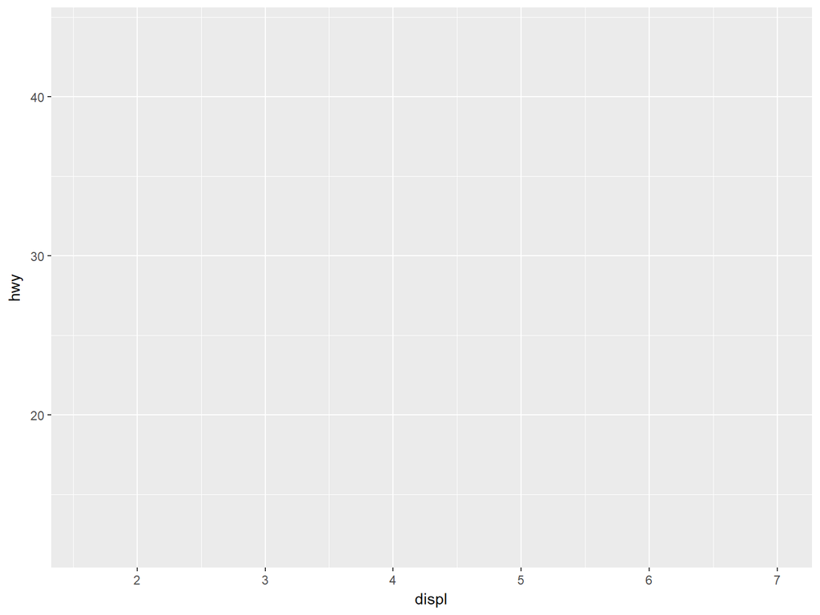

```r
ggplot(data=mpg,aes(x=displ,y=hwy))
```

2. +그래프

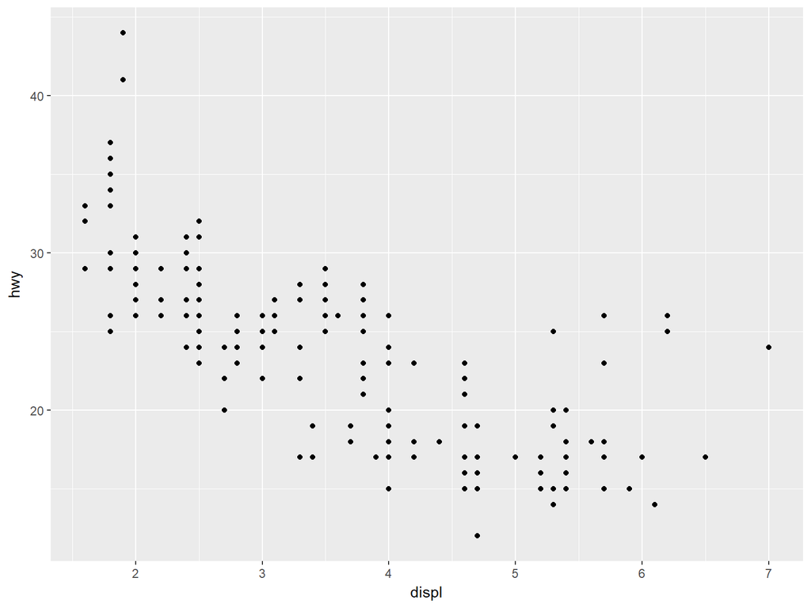

```r
ggplot(data=mpg, aes(x=displ,y=hwy))+
  geom_point()
```

`geom_point()` 는 scatterplot, 즉 산점도를 그리는 커맨드입니다.

- +설정추가

이번에는 x축의 범위를 임의로 설정하겠습니다.

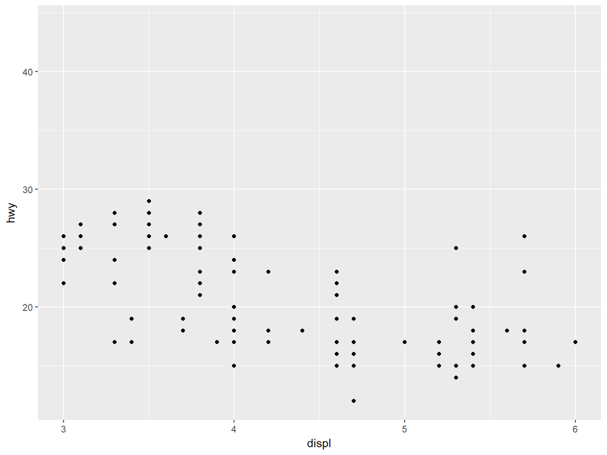

```r
ggplot(data=mpg,aes(x=displ,y=hwy))+
  geom_point()+
  xlim(3,6)
```

## Time Series Graph

- 이번에는 time series data를 ggplot2로 그려보겠습니다.

R의 economics라는 데이터를 사용합니다.

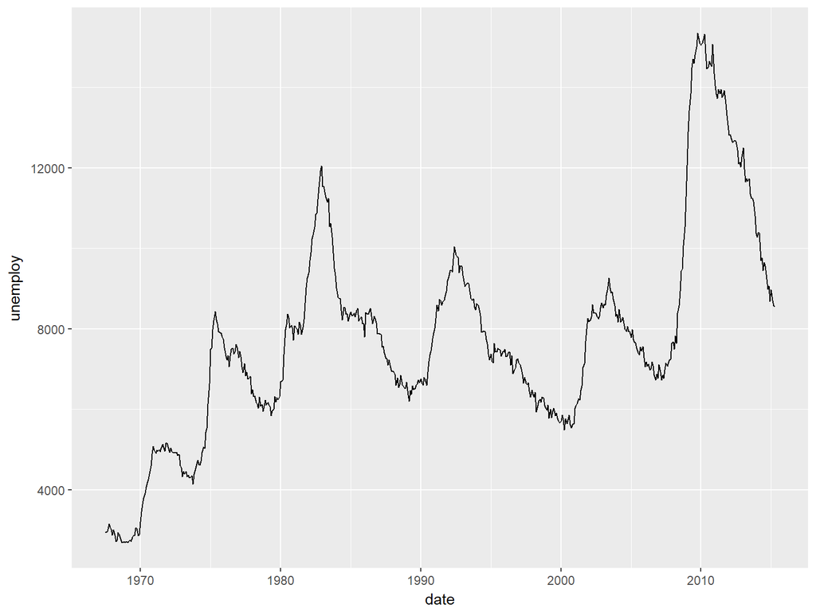

```r
ggplot(data=economics, aes(x=date,y=unemploy))+
  geom_line()
```

- 참고로 Econometrics에는 Time series econometrics라는 기법이 존재합니다. 이 regression method를 통해 시간열 데이터를 분석하고 또는 간단한 예측또한 가능합니다. 그러나 저희 스터디를 현재 진행중인 저의 한계로 인해 그 파트는 설명하지 않고 넘어갑니다.

## 데이터 전처리

- 데이터의 전처리는 데이터 분석에 앞서 가장 중요한 파트입니다. 논문을 여럿 읽어보신 분들은 아시겠지만, 대부분의 연구자들은 이 데이터의 전처리에 literature review를 제외하고 가장 많은 시간을 투자하는 경우가 허다합니다.

R에서 이러한 전처리를 도와주는 패키지들이 있는데, 바로 `dplyr`과 `data.table` 패키지입니다.

## Prerequisites

아래 코드를 실행할 때에 # 는 빼고 작성하세요

```r
# install.packages("tidyverse")
```

`tidyverse` 는 일종의 R의 “입문용 패키지들의 패키지”라고 보시면 됩니다. 이 패키지는 아래와 같은 패키지들을 첨부하고 있습니다.

- ggplot2
- tibble
- readr
- purrr
- dplyr

## Call tidyverse

tidyverse 패키지를 부릅니다.

```r
library(tidyverse)
```

## Tibble이란

Tibble은 현재 R 내에서 빠른 속도로 그 쓰임새가 늘고 있는 “데이터 타입” 입니다. 보통 STATA,SPSS,EXCEL, R 등의 통계언어들은 data frame(DF) 이라는 데이터 타입을 사용합니다(굉장히 efficient한 포멧입니다). 그런데 이러한 DF들의 단점은 DF를 call 할 경우, 데이터 전체를 프린트를 할 문제점이 있다는 겁니다 (잘못하면 컴퓨터나 프로그램이 삐져서 파업합니다).

그리고 DF는 각 variable이 무슨 타입인지를 데이터만 봐서는 모른다는 단점이 있습니다. STATA를 좀 쓰신 분들은 아시겠지만, data type에 따라서 사람 속터지게 만드는 경우가 가끔 있지요…(excel에서 currency 면 stata는 그걸 숫자가 아닌 단어로 인식하는 놀라운 인식능력을 갖추고 있습니다…왜???)

R 또한 그 정도는 아니지만 그래도 가끔씩 귀찮을 때가 좀 있습니다. 그런데 tibble은 이러한 점들을 여러모로 커버를 해줍니다.

## Tibble(1): iris dataset

```r
data("iris")
class(iris)
```

```
## [1] "data.frame"
```

```r
iris
```

```
##     Sepal.Length Sepal.Width Petal.Length Petal.Width    Species
## 1            5.1         3.5          1.4         0.2     setosa
## 2            4.9         3.0          1.4         0.2     setosa
## 3            4.7         3.2          1.3         0.2     setosa
## 4            4.6         3.1          1.5         0.2     setosa
## 5            5.0         3.6          1.4         0.2     setosa
## 6            5.4         3.9          1.7         0.4     setosa
## 7            4.6         3.4          1.4         0.3     setosa
## 8            5.0         3.4          1.5         0.2     setosa
## 9            4.4         2.9          1.4         0.2     setosa
## 10           4.9         3.1          1.5         0.1     setosa
## 11           5.4         3.7          1.5         0.2     setosa
## 12           4.8         3.4          1.6         0.2     setosa
## 13           4.8         3.0          1.4         0.1     setosa
## 14           4.3         3.0          1.1         0.1     setosa
```

[output cut: 136 more lines]

## Tibble(2): Convert dataframe to tibble

```r
my_iris <- as_data_frame(iris)
class(my_iris)
```

```
## [1] "tbl_df"     "tbl"        "data.frame"
```

```r
my_iris
```

```
## # A tibble: 150 x 5
##    Sepal.Length Sepal.Width Petal.Length Petal.Width Species
##           <dbl>       <dbl>        <dbl>       <dbl>  <fctr>
##  1          5.1         3.5          1.4         0.2  setosa
##  2          4.9         3.0          1.4         0.2  setosa
##  3          4.7         3.2          1.3         0.2  setosa
##  4          4.6         3.1          1.5         0.2  setosa
##  5          5.0         3.6          1.4         0.2  setosa
##  6          5.4         3.9          1.7         0.4  setosa
##  7          4.6         3.4          1.4         0.3  setosa
##  8          5.0         3.4          1.5         0.2  setosa
##  9          4.4         2.9          1.4         0.2  setosa
## 10          4.9         3.1          1.5         0.1  setosa
## # ... with 140 more rows
```

## Data Transformation

```r
library(data.table)
# install.packages("nycflights13")
library(nycflights13)
```

이번에는 두개의 데이터를 합치는 일을 해보겠습니다.

```r
flights
```

```
## # A tibble: 336,776 x 19
##     year month   day dep_time sched_dep_time dep_delay arr_time
##    <int> <int> <int>    <int>          <int>     <dbl>    <int>
##  1  2013     1     1      517            515         2      830
##  2  2013     1     1      533            529         4      850
##  3  2013     1     1      542            540         2      923
##  4  2013     1     1      544            545        -1     1004
##  5  2013     1     1      554            600        -6      812
##  6  2013     1     1      554            558        -4      740
##  7  2013     1     1      555            600        -5      913
##  8  2013     1     1      557            600        -3      709
##  9  2013     1     1      557            600        -3      838
## 10  2013     1     1      558            600        -2      753
## # ... with 336,766 more rows, and 12 more variables: sched_arr_time <int>,
## #   arr_delay <dbl>, carrier <chr>, flight <int>, tailnum <chr>,
## #   origin <chr>, dest <chr>, air_time <dbl>, distance <dbl>, hour <dbl>,
## #   minute <dbl>, time_hour <dttm>
```

```r
planes
```

```
## # A tibble: 3,322 x 9
##    tailnum  year                    type     manufacturer     model
##      <chr> <int>                   <chr>            <chr>     <chr>
##  1  N10156  2004 Fixed wing multi engine          EMBRAER EMB-145XR
##  2  N102UW  1998 Fixed wing multi engine AIRBUS INDUSTRIE  A320-214
##  3  N103US  1999 Fixed wing multi engine AIRBUS INDUSTRIE  A320-214
##  4  N104UW  1999 Fixed wing multi engine AIRBUS INDUSTRIE  A320-214
##  5  N10575  2002 Fixed wing multi engine          EMBRAER EMB-145LR
##  6  N105UW  1999 Fixed wing multi engine AIRBUS INDUSTRIE  A320-214
##  7  N107US  1999 Fixed wing multi engine AIRBUS INDUSTRIE  A320-214
##  8  N108UW  1999 Fixed wing multi engine AIRBUS INDUSTRIE  A320-214
##  9  N109UW  1999 Fixed wing multi engine AIRBUS INDUSTRIE  A320-214
## 10  N110UW  1999 Fixed wing multi engine AIRBUS INDUSTRIE  A320-214
## # ... with 3,312 more rows, and 4 more variables: engines <int>,
## #   seats <int>, speed <int>, engine <chr>
```

- 이 두 데이터의 같은점은 무엇일까요?